# Applied Stats problem statement

```python
import numpy as np
import pandas as pd
from matplotlib import pyplot as plt
```

```python
import seaborn as sns
sns.set()
import statsmodels.api as sm
import scipy.stats as stats
from sklearn.preprocessing import LabelEncoder
```

```python
import copy
import os
```

```python
# Read the csv
insurance_df = pd.read_csv("insurance.csv")
```

```python
#Display first 10 dataset
insurance_df.head(10)
```

|  | age | sex | bmi | children | smoker | region | charges |
| --- | --- | --- | --- | --- | --- | --- | --- |
| 0 | 19 | female | 27.900 | 0 | yes | southwest | 16884.92400 |
| 1 | 18 | male | 33.770 | 1 | no | southeast | 1725.55230 |
| 2 | 28 | male | 33.000 | 3 | no | southeast | 4449.46200 |
| 3 | 33 | male | 22.705 | 0 | no | northwest | 21984.47061 |
| 4 | 32 | male | 28.880 | 0 | no | northwest | 3866.85520 |
| 5 | 31 | female | 25.740 | 0 | no | southeast | 3756.62160 |
| 6 | 46 | female | 33.440 | 1 | no | southeast | 8240.58960 |
| 7 | 37 | female | 27.740 | 3 | no | northwest | 7281.50560 |
| 8 | 37 | male | 29.830 | 2 | no | northeast | 6406.41070 |
| 9 | 60 | female | 25.840 | 0 | no | northwest | 28923.13692 |

Perform basic EDA

a. Shape of the data

b. Data type of each attribute

c. Checking the presence of missing values

d. 5 point summary of numerical attributes

e. Distribution of ‘bmi’, ‘age’ and ‘charges’ columns.

f. Measure of skewness of ‘bmi’, ‘age’ and ‘charges’ columns

g. Checking the presence of outliers in ‘bmi’, ‘age’ and ‘charges columns

h. Distribution of categorical columns (include children)

i. Pair plot that includes all the columns of the data frame

```python
#a. Shape of the data

#b. Data type of each attribute

insurance_df.info()
```

```
<class 'pandas.core.frame.DataFrame'>
RangeIndex: 1338 entries, 0 to 1337
Data columns (total 7 columns):
age         1338 non-null int64
sex         1338 non-null object
bmi         1338 non-null float64
children    1338 non-null int64
smoker      1338 non-null object
region      1338 non-null object
charges     1338 non-null float64
dtypes: float64(2), int64(2), object(3)
memory usage: 73.3+ KB
```

The data has 1338 instances with 7 attributes. 2 integer type, 2 float type and 3 object type(Strings in the column)

```python
#Check the presence of missing values

insurance_df.isna().apply(pd.value_counts)
```

|  | age | sex | bmi | children | smoker | region | charges |
| --- | --- | --- | --- | --- | --- | --- | --- |
| False | 1338 | 1338 | 1338 | 1338 | 1338 | 1338 | 1338 |

**There are no null values in the dataset**

```python
#5 point summary for the dataset
insurance_df.describe().T
```

|  | count | mean | std | min | 25% | 50% | 75% | max |
| --- | --- | --- | --- | --- | --- | --- | --- | --- |
| age | 1338.0 | 39.207025 | 14.049960 | 18.0000 | 27.00000 | 39.000 | 51.000000 | 64.00000 |
| bmi | 1338.0 | 30.663397 | 6.098187 | 15.9600 | 26.29625 | 30.400 | 34.693750 | 53.13000 |
| children | 1338.0 | 1.094918 | 1.205493 | 0.0000 | 0.00000 | 1.000 | 2.000000 | 5.00000 |
| charges | 1338.0 | 13270.422265 | 12110.011237 | 1121.8739 | 4740.28715 | 9382.033 | 16639.912515 | 63770.42801 |

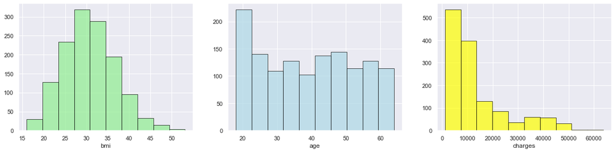

```python
#Plots to see the distribution

plt.figure(figsize= (20,15))
plt.subplot(3,3,1)
plt.hist(insurance_df.bmi, color='lightgreen', edgecolor = 'black', alpha = 0.7)
plt.xlabel('bmi')

plt.subplot(3,3,2)
plt.hist(insurance_df.age, color='lightblue', edgecolor = 'black', alpha = 0.7)
plt.xlabel('age')

plt.subplot(3,3,3)
plt.hist(insurance_df.charges, color='yellow', edgecolor = 'black', alpha = 0.7)
plt.xlabel('charges')

plt.show()
```

- bmi normally distributed
- Age is uniformly distributed
- Chareges is skewed

```python
#Measure of skewness of ‘bmi’, ‘age’ and ‘charges’column

Skewness = pd.DataFrame({'Skewness' : [stats.skew(insurance_df.bmi),stats.skew(insurance_df.age),stats.skew(insurance_df.charges)]},
                        index=['bmi','age','charges'])
Skewness
```

|  | Skewness |
| --- | --- |
| bmi | 0.283729 |
| age | 0.055610 |
| charges | 1.514180 |

- Skew of bmi is very less
- age is uniformly distributed no skew
- charges is highly skewed

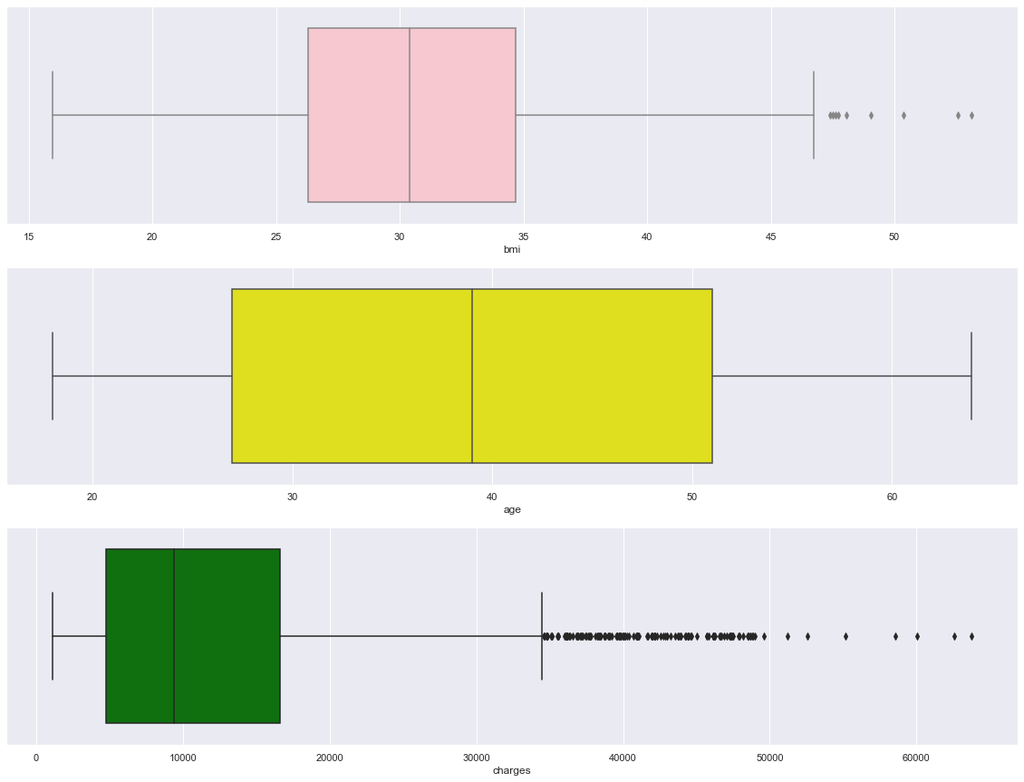

```python
#Checking for the outliers

plt.figure(figsize= (20,15))
plt.subplot(3,1,1)
sns.boxplot(x= insurance_df.bmi, color='pink')

plt.subplot(3,1,2)
sns.boxplot(x= insurance_df.age, color='yellow')

plt.subplot(3,1,3)
sns.boxplot(x= insurance_df.charges, color='green')

plt.show()
```

- bmi has a few outliers, age doesnt have
- charges as it is highly skewed, there are a lot of extreme values

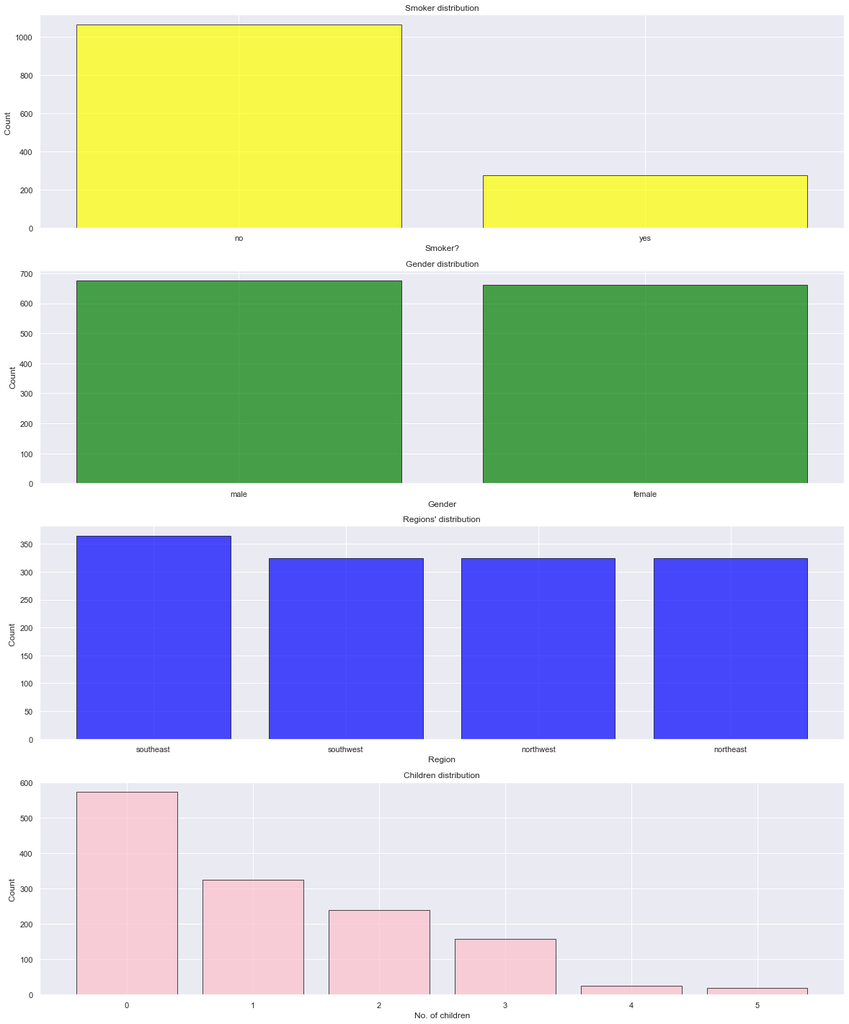

```python
#Distribution of categorical columns (includechildren)


plt.figure(figsize=(20,25))


x = insurance_df.smoker.value_counts().index    # x-axis
y = [insurance_df['smoker'].value_counts()[i] for i in x]   #  y-axis

plt.subplot(4,1,1)
plt.bar(x,y, align='center',color = 'yellow',edgecolor = 'black',alpha = 0.7)
plt.xlabel('Smoker?')
plt.ylabel('Count ')
plt.title('Smoker distribution')

x1 = insurance_df.sex.value_counts().index
y1 = [insurance_df['sex'].value_counts()[j] for j in x1]

plt.subplot(4,1,2)
plt.bar(x1,y1, align='center',color = 'green',edgecolor = 'black',alpha = 0.7)
plt.xlabel('Gender')
plt.ylabel('Count')
plt.title('Gender distribution')

x2 = insurance_df.region.value_counts().index
y2 = [insurance_df['region'].value_counts()[k] for k in x2]

plt.subplot(4,1,3)
plt.bar(x2,y2, align='center',color = 'blue',edgecolor = 'black',alpha = 0.7)
plt.xlabel('Region')
plt.ylabel('Count ')
plt.title("Regions' distribution")

x3 = insurance_df.children.value_counts().index
y3 = [insurance_df['children'].value_counts()[l] for l in x3]

plt.subplot(4,1,4)
plt.bar(x3,y3, align='center',color = 'pink',edgecolor = 'black',alpha = 0.7)
plt.xlabel('No. of children')
plt.ylabel('Count ')
plt.title("Children distribution")

plt.show()
```

- nonSmokers are more than smokers
- Instances and Gender are distributed evenly accross all regions
- Mostly ppl have 1 to 3 childrens

Bi-variate distribution of every possible attribute pair

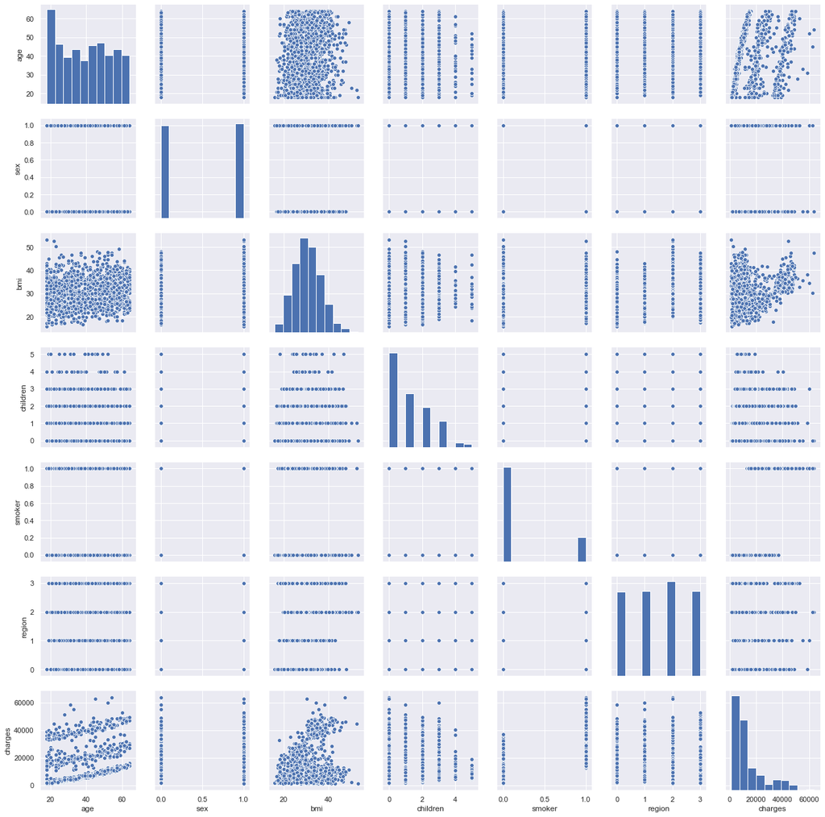

```python
insurance_df_encoded = copy.deepcopy(insurance_df)
insurance_df_encoded.loc[:,['sex', 'smoker', 'region']] = insurance_df_encoded.loc[:,['sex', 'smoker', 'region']].apply(LabelEncoder().fit_transform)

sns.pairplot(insurance_df_encoded)
plt.show()
```

- 'charges' is correlated with 'smoker'
- smoker charges are more than non-smokers

## Do charges of people who smoke differ significantly from the people who don't?

```python
insurance_df.smoker.value_counts()
```

```
no     1064
yes     274
Name: smoker, dtype: int64
```

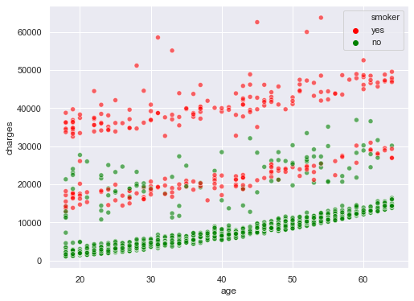

```python
# Do charges of people who smoke differ significantly from the people who don't?

plt.figure(figsize=(8,6))
sns.scatterplot(insurance_df.age, insurance_df.charges,hue=insurance_df.smoker,palette= ['red','green'] ,alpha=0.6)
plt.show()
```

```python
# T-test to check dependency of smoking on charges
Ho = "Charges of smoker and non-smoker are same"   # Stating the Null Hypothesis
Ha = "Charges of smoker and non-smoker are not the same"   # Stating the Alternate Hypothesis

x = np.array(insurance_df[insurance_df.smoker == 'yes'].charges)  # Selecting charges corresponding to smokers as an array
y = np.array(insurance_df[insurance_df.smoker == 'no'].charges) # Selecting charges corresponding to non-smokers as an array

t, p_value  = stats.ttest_ind(x,y, axis = 0)  #Performing an Independent t-test

if p_value < 0.05:  # Setting our significance level at 5%
    print(f'{Ha} as the p_value ({p_value}) < 0.05')
else:
    print(f'{Ho} as the p_value ({p_value}) > 0.05')
```

```
Charges of smoker and non-smoker are not the same as the p_value (8.271435842177219e-283) < 0.05
```

**Smokers claim more money than non-smokers**

## Does bmi of males differ significantly from that of females?

```python
insurance_df.sex.value_counts()   #Checking  distribution for males and females
```

```
male      676
female    662
Name: sex, dtype: int64
```

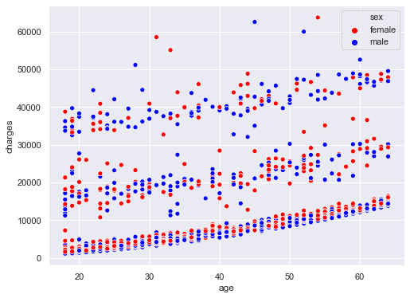

```python
plt.figure(figsize=(8,6))
sns.scatterplot(insurance_df.age, insurance_df.charges,hue=insurance_df.sex,palette= ['red','blue'] )
plt.show()
```

- Visually, there is no apparent relation between gender and charges

```python
# T-test to check dependency of bmi on gender
Ho = "Gender has no effect on bmi"   #Null Hypothesis
Ha = "Gender has an effect on bmi"   #Alternate Hypothesis

x = np.array(insurance_df[insurance_df.sex == 'male'].bmi)  # males bmi
y = np.array(insurance_df[insurance_df.sex == 'female'].bmi) # females bmi

t, p_value  = stats.ttest_ind(x,y, axis = 0)

if p_value < 0.05:
    print(f'{Ha} as the p_value ({p_value.round()}) < 0.05')
else:
    print(f'{Ho} as the p_value ({p_value.round(3)}) > 0.05')
```

```
Gender has no effect on bmi as the p_value (0.09) > 0.05
```

##### bmi of both the genders are same

## Is the proportion of smokers significantly different in different genders?

```python
# Chi_square
Ho = "Gender has no effect on smoking habits"   #  Null Hypothesis
Ha = "Gender has an effect on smoking habits"   #  Alternate Hypothesis

ss = pd.crosstab(insurance_df['sex'],insurance_df['smoker'])

chi, p_value, dof, expected =  stats.chi2_contingency(ss)

if p_value < 0.05:  # Setting our significance level at 5%
    print(f'{Ha} as the p_value ({p_value.round(3)}) < 0.05')
else:
    print(f'{Ho} as the p_value ({p_value.round(3)}) > 0.05')
ss
```

```
Gender has an effect on smoking habits as the p_value (0.007) < 0.05
```

| smoker sex | no | yes |
| --- | --- | --- |
| female | 547 | 115 |
| male | 517 | 159 |

**Proportion of smokers in males is significantly different from that of the females**

## Is the distribution of bmi across women with no children, one child and two children, the same ?

```python
#  Null Hypothesis
Ho = "No. of children has no effect on bmi"

# Alternate Hypothesis
Ha = "No. of children has an effect on bmi"


female_df = copy.deepcopy(insurance_df[insurance_df['sex'] == 'female'])

zero = female_df[female_df.children == 0]['bmi']
one = female_df[female_df.children == 1]['bmi']
two = female_df[female_df.children == 2]['bmi']


f_stat, p_value = stats.f_oneway(zero,one,two)


if p_value < 0.05:
    print(f'{Ha} as the p_value ({p_value.round(3)}) < 0.05')
else:
    print(f'{Ho} as the p_value ({p_value.round(3)}) > 0.05')
```

```
No. of children has no effect on bmi as the p_value (0.716) > 0.05
```

##### *BMI is not changed by the number of children a women has